# Professional Hockey Exploratory Data Analysis

Vince Trost

December 15, 2016

*Source file* ⇒ Hockey.Rmd

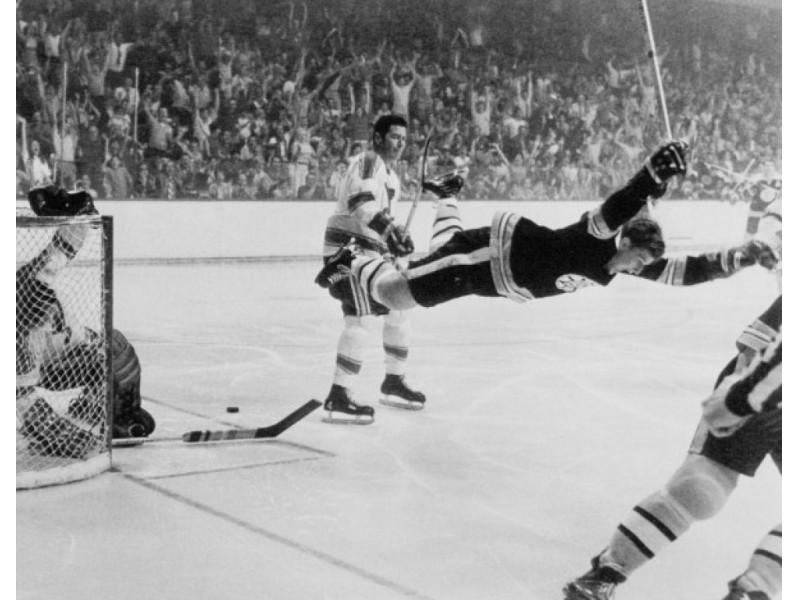

For my project, I chose to analyze some data on Professional Hockey teams. **I want to find out what Stanley Cup winners have in common, and if there are any trends in the data that might forego the obvious needs for winning the Cup.** So I’m going to try a boatload of things :).

First things first, I got this data from **Kaggle**. The URL can be found [here](https://www.kaggle.com/open-source-sports/professional-hockey-database). I went down the page and looked at the different files they had listed. The one that was of interest to me was the `Teams.csv`. This contained the following data for each team in each year from 1909 to 2011:

- **year:** Year (2005-06 listed as “2005”)
- **lgID:** League ID
- **tmID:** Team ID
- **franchID:** Franchise ID
- **confID:** Conference ID (see abbrev.csv for details)
- **divID:** Division ID (see abbrev.csv for details)
- **rank:** Final standing
- **playoff:** Playoff result (see abbrev.csv for details)
- **G:** Games
- **W:** Wins
- **L:** Losses
- **T:** Ties
- **OTL:** Overtime losses
- **Pts:** Points
- **SoW:** Shootout wins
- **SoL:** Shootout losses
- **GF:** Goals for
- **GA:** Goals against
- **name:** Full team name
- **PIM:** Penalty minutes
- **BenchMinor:** Bench minors (minutes)
- **PPG:** Power play goals
- **PPC:** Power play chances
- **SHA:** Shorthanded goals against
- **PKG:** Power play goals against
- **PKC:** Penalty kill chances
- **SHF:** Shorthanded goals for

As you can see, I needed the `abbrev.csv` as well. I loaded them both in after I put the csv’s in the working directory with the following commands:

```r
abbrev <- read.csv("abbrev.csv")
teams <- read.csv("Teams.csv")
```

The abbreviations are explained below:

| Type | Code | Fullname |
| --- | --- | --- |
| Playoffs | NHAF | Lost NHA finals |
| Playoffs | NHLF | Lost NHL finals |
| Playoffs | CQF | Lost NHL conference quarter-finals |
| Playoffs | PRE | Lost NHL preliminary round |
| Playoffs | F | Lost Stanley Cup finals |
| Playoffs | CSF | Lost NHL conference semi-finals |
| Playoffs | CF | Lost NHL conference finals |
| Playoffs | SC | Won Stanley Cup |
| Playoffs | DF | Lost NHL division finals |
| Playoffs | QF | Lost NHL quarter-finals |
| Playoffs | SF | Lost NHL semi-finals |
| Playoffs | DSF | Lost NHL division semi-finals |
| Playoffs | ND | ND - Stanley Cup finals halted (influenza epidemic) |
| Playoffs | AVC | Won AVCO Cup |
| Playoffs | AVF | Lost AVCO Cup finals |
| Playoffs | AVSF | Lost AVCO Cup semi-finals |
| Playoffs | AVQF | Lost AVCO Cup quarter-finals |
| Playoffs | AVPRE | Lost AVCO Cup preliminary round |
| Playoffs | WSF | Lost WCHL semi-finals |
| Playoffs | WF | Lost WCHL finals |
| Playoffs | PF | Lost PCHA finals |
| Playoffs | SCSF | Lost Stanley Cup semi-finals |
| Playoffs | WCS | Won Challenge Series |
| Playoffs | LCS | Won Stanley Cup / Lost Challenge Series |
| Conference | CC | Campbell Conference |
| Conference | WA | Wales Conference |
| Conference | EC | Eastern Conference |
| Conference | WC | Western Conference |
| Division | AM | American Division |
| Division | CA | Canadian Division |
| Division | ED | East Division |
| Division | WD | West Division |
| Division | PT | Patrick Division |
| Division | AD | Adams Division |
| Division | NO | Norris Division |
| Division | SM | Smythe Division |
| Division | AT | Atlantic Division |
| Division | NE | Northeast Division |
| Division | SE | Southeast Division |
| Division | CE | Central Division |
| Division | NW | Northwest Division |
| Division | PC | Pacific Division |
| Division | EW | WHA East Division |
| Division | WW | WHA West Division |
| Division | CW | WHA Canadian Division |
| Round | QF | Quarter-Finals |
| Round | SF | Semi-Finals |
| Round | F | Finals |
| Round | WP | Western Playoff |
| Round | SCF | Stanley Cup Finals |
| Round | SCSF | Stanley Cup Semi-Finals |
| Round | Pre | Preliminary |
| Round | DSF | Division Semi-Finals |
| Round | DF | Division Finals |
| Round | CQF | Conference Quarter-Finals |
| Round | CSF | Conference Semi-Finals |
| Round | CF | Conference Finals |
| Round | ACF | Avco Cup Finals |

I want to find out the key tell-tale signs that a team is going to win the cup. Ideally, I’d like to come up with a magical formula for winning the cup (far fetched, I know). I have a few hypotheses I want to test to uncover my magical formula. But first I want to see some things.

### More Goals, More Success?

The first thing I want to know is **what percentage of history’s highest scoring teams won the cup?** You’ve got to score goals to win- how often do the most powerful offensive teams in history win it all?

[figure not shown]

Let’s find out what teams were the highest scoring teams in history. To do that we will arrange the `teams` table by Goals For (`GF`)

```r
lampLighters <- teams %>%
  arrange(desc(GF))
kable(head(lampLighters))
```

| year | lgID | tmID | franchID | confID | divID | rank | playoff | G | W | L | T | OTL | Pts | SoW | SoL | GF | GA | name | PIM | BenchMinor | PPG | PPC | SHA | PKG | PKC | SHF |
| --- | --- | --- | --- | --- | --- | --- | --- | --- | --- | --- | --- | --- | --- | --- | --- | --- | --- | --- | --- | --- | --- | --- | --- | --- | --- | --- |
| 1983 | NHL | EDM | EDM | CC | SM | 1 | SC | 80 | 57 | 18 | 5 | NA | 119 | NA | NA | 446 | 314 | Edmonton Oilers | 1577 | 18 | 81 | 318 | 12 | 77 | 386 | 36 |
| 1985 | NHL | EDM | EDM | CC | SM | 1 | DF | 80 | 56 | 17 | 7 | NA | 119 | NA | NA | 426 | 310 | Edmonton Oilers | 1928 | 28 | 78 | 295 | 15 | 77 | 409 | 27 |
| 1982 | NHL | EDM | EDM | CC | SM | 1 | F | 80 | 47 | 21 | 12 | NA | 106 | NA | NA | 424 | 315 | Edmonton Oilers | 1771 | 28 | 86 | 294 | 6 | 89 | 396 | 22 |
| 1981 | NHL | EDM | EDM | CC | SM | 1 | DSF | 80 | 48 | 17 | 15 | NA | 111 | NA | NA | 417 | 295 | Edmonton Oilers | 1473 | 20 | 86 | 341 | 8 | 67 | 371 | 12 |
| 1984 | NHL | EDM | EDM | CC | SM | 1 | SC | 80 | 49 | 20 | 11 | NA | 109 | NA | NA | 401 | 298 | Edmonton Oilers | 1567 | 12 | 74 | 293 | 5 | 76 | 353 | 25 |
| 1970 | NHL | BOS | BOS |  | ED | 1 | QF | 78 | 57 | 14 | 7 | NA | 121 | NA | NA | 399 | 207 | Boston Bruins | 1156 | 8 | 80 | 289 | 4 | 53 | 336 | 25 |

Wow ok. So the **Edmonton Oilers** from 1981-1985 were pretty dang good. Seems about right though- a quick Google search showed that Wayne Gretzky (arguably hockey’s greatest player), who played for the Oilers during that time, was consistently breaking his own records during the years of 1980-81 through 1985-86. That would definitely help in a Stanley Cup effort. Incredibly though, they only won in ’83 and ’84. Just goes to show there’s no I in Team, and that you need to supplement and support superstar talent. I digress…  
So 2/5 for the Oilers is really not that bad- but let’s look at the bigger picture here… of the so-called `lampLighters`, let’s take the top 25% and see who actually won the cup with all their offensive firepower.

```r
top25lampLighters <- lampLighters %>%
  filter(rank(desc(GF))<= 1519/4)
offensiveWinners <- top25lampLighters %>%
  filter(playoff == 'SC') %>%
  arrange(desc(year))
nrow(offensiveWinners)
```

```
## [1] 26
```

```r
kable(head(offensiveWinners, 5))
```

| year | lgID | tmID | franchID | confID | divID | rank | playoff | G | W | L | T | OTL | Pts | SoW | SoL | GF | GA | name | PIM | BenchMinor | PPG | PPC | SHA | PKG | PKC | SHF |
| --- | --- | --- | --- | --- | --- | --- | --- | --- | --- | --- | --- | --- | --- | --- | --- | --- | --- | --- | --- | --- | --- | --- | --- | --- | --- | --- |
| 2005 | NHL | CAR | CAR | EC | SE | 1 | SC | 82 | 52 | 22 | NA | 8 | 112 | 8 | 2 | 294 | 260 | Carolina Hurricanes | 1125 | 18 | 95 | 531 | 13 | 81 | 445 | 17 |
| 1995 | NHL | COL | COL | WC | PC | 1 | SC | 82 | 47 | 25 | 10 | NA | 104 | NA | NA | 326 | 240 | Colorado Avalanche | 1536 | 22 | 86 | 404 | 22 | 71 | 439 | 21 |
| 1993 | NHL | NYR | NYR | EC | AT | 1 | SC | 84 | 52 | 24 | 8 | NA | 112 | NA | NA | 299 | 231 | New York Rangers | 1688 | 20 | 96 | 417 | 5 | 67 | 435 | 20 |
| 1992 | NHL | MTL | MTL | WA | AD | 3 | SC | 84 | 48 | 30 | 6 | NA | 102 | NA | NA | 326 | 280 | Montreal Canadiens | 1788 | 8 | 79 | 430 | 13 | 77 | 427 | 8 |
| 1991 | NHL | PIT | PIT | WA | PT | 3 | SC | 80 | 39 | 32 | 9 | NA | 87 | NA | NA | 343 | 308 | Pittsburgh Penguins | 1907 | 12 | 92 | 423 | 14 | 77 | 383 | 16 |

Of the top 25% of the NHL’s highest scoring teams in history, only less than **7%** of the time do they go on to win the cup. That’s incredible. How did I get those numbers?  
The top 25% is 380 teams. Of those teams, only 26 won the cup (which equals about 6.8%). So a 7% Stanley Cup win percentage isn’t exactly the formula for success I was looking for. Let’s try some other seemingly logical things.

### “You’ve got to find a way to win”

Well, other than scoring goals, you’ve got to win games in order to be successful. That doesn’t necessarily mean scoring more goals will help you win, but there are those teams that seem to win no matter how tight the margin. Hockey people like to describe those teams as *teams that find ways to win*.  
So the question here is- **what percentage of the NHL’s most winningest teams in history during the regular season go on to win the Stanley Cup?**  
Let’s find out the most winningest teams in NHL history.

```r
winners <- teams %>%
  arrange(desc(W))
kable(head(winners))
```

| year | lgID | tmID | franchID | confID | divID | rank | playoff | G | W | L | T | OTL | Pts | SoW | SoL | GF | GA | name | PIM | BenchMinor | PPG | PPC | SHA | PKG | PKC | SHF |
| --- | --- | --- | --- | --- | --- | --- | --- | --- | --- | --- | --- | --- | --- | --- | --- | --- | --- | --- | --- | --- | --- | --- | --- | --- | --- | --- |
| 1995 | NHL | DET | DET | WC | CE | 1 | CF | 82 | 62 | 13 | 7 | NA | 131 | NA | NA | 325 | 181 | Detroit Red Wings | 1551 | 18 | 97 | 455 | 9 | 44 | 375 | 17 |
| 1976 | NHL | MTL | MTL | WA | NO | 1 | SC | 80 | 60 | 8 | 12 | NA | 132 | NA | NA | 387 | 171 | Montreal Canadiens | 764 | 10 | 59 | 237 | 3 | 28 | 231 | 5 |
| 1977 | NHL | MTL | MTL | WA | NO | 1 | SC | 80 | 59 | 10 | 11 | NA | 129 | NA | NA | 359 | 183 | Montreal Canadiens | 745 | 10 | 73 | 229 | 1 | 40 | 211 | 9 |
| 1975 | NHL | MTL | MTL | WA | NO | 1 | SC | 80 | 58 | 11 | 11 | NA | 127 | NA | NA | 337 | 174 | Montreal Canadiens | 977 | 14 | 75 | 282 | 0 | 44 | 290 | 7 |
| 2005 | NHL | DET | DET | WC | CE | 1 | CQF | 82 | 58 | 16 | NA | 8 | 124 | 4 | 3 | 305 | 209 | Detroit Red Wings | 1117 | 14 | 102 | 461 | 10 | 67 | 461 | 7 |
| 1970 | NHL | BOS | BOS |  | ED | 1 | QF | 78 | 57 | 14 | 7 | NA | 121 | NA | NA | 399 | 207 | Boston Bruins | 1156 | 8 | 80 | 289 | 4 | 53 | 336 | 25 |

Awesome, so the most winningest teams are winning upwards of 60 games a year. Let’s do the same thing except this time, let’s get the top 15% of them.

```r
top15winners <- winners %>%
  filter(rank(desc(W))<=228)
nrow(top15winners)
```

```
## [1] 229
```

Now, how many of these teams **won the cup?!**

[figure not shown]

```r
wayfinders <- top15winners %>%
  filter(playoff == 'SC') %>%
  arrange(desc(year))
nrow(wayfinders)
```

```
## [1] 34
```

Of the 229 most winningest teams in NHL history, only 34 of them *FOUND A WAY* to **keep** winning through the playoffs. So the strategy of winning a ton of games to try and win the cup is coming in at a payoff rate of about **14.8%**. That’s double the success rate of just scoring a lot. Improvement!  
So we know that winning games is important, and that scoring goals helps win games. What else can help win Lord Stanley’s Cup?

### What Makes a Chamionship-Winning Team?

Well, if you’re going to score a lot, you need to make sure your opponents aren’t scoring just as much if not more than you! So let’s minimize the Goals Allowed (`GA`)! This signifies not only a strong offense, but a strong defense and good goaltending- putting together the pieces for a championship-winning team. These are **beast** teams. Therefore we will call them `beasts`.  
We can do this by creating another variable we will call `GD` for Goal Differential, where GD = GF-GA. So the question here is: **what percentage of teams with high goal differentials (GF-GA) go on to win the Stanley Cup?**

```r
#add a column for computing the Goal Differential
teams <- teams %>%
  mutate(GD = (GF-GA))
#Order by teams that have the highest GD
beasts <- teams %>%
  arrange(desc(GD))
kable(head(beasts, 5))
```

| year | lgID | tmID | franchID | confID | divID | rank | playoff | G | W | L | T | OTL | Pts | SoW | SoL | GF | GA | name | PIM | BenchMinor | PPG | PPC | SHA | PKG | PKC | SHF | GD |
| --- | --- | --- | --- | --- | --- | --- | --- | --- | --- | --- | --- | --- | --- | --- | --- | --- | --- | --- | --- | --- | --- | --- | --- | --- | --- | --- | --- |
| 1976 | NHL | MTL | MTL | WA | NO | 1 | SC | 80 | 60 | 8 | 12 | NA | 132 | NA | NA | 387 | 171 | Montreal Canadiens | 764 | 10 | 59 | 237 | 3 | 28 | 231 | 5 | 216 |
| 1970 | NHL | BOS | BOS |  | ED | 1 | QF | 78 | 57 | 14 | 7 | NA | 121 | NA | NA | 399 | 207 | Boston Bruins | 1156 | 8 | 80 | 289 | 4 | 53 | 336 | 25 | 192 |
| 1977 | NHL | MTL | MTL | WA | NO | 1 | SC | 80 | 59 | 10 | 11 | NA | 129 | NA | NA | 359 | 183 | Montreal Canadiens | 745 | 10 | 73 | 229 | 1 | 40 | 211 | 9 | 176 |
| 1975 | NHL | MTL | MTL | WA | NO | 1 | SC | 80 | 58 | 11 | 11 | NA | 127 | NA | NA | 337 | 174 | Montreal Canadiens | 977 | 14 | 75 | 282 | 0 | 44 | 290 | 7 | 163 |
| 1974 | NHL | MTL | MTL | WA | NO | 1 | SF | 80 | 47 | 14 | 19 | NA | 113 | NA | NA | 374 | 225 | Montreal Canadiens | 1155 | 14 | 92 | 350 | 10 | 54 | 314 | 8 | 149 |

So the **beast** teams have massive goal differentials. But from rank 5 to 1 is a difference of 67 goals, so that tells me I want to keep my cutoff for being a **topBeast** team rather high. Let’s do top 10%.

```r
topBeasts <- beasts %>%
  filter(rank(desc(GD))<=152)
nrow(topBeasts)
```

```
## [1] 151
```

So we have the top 10% of the **beast** teams with high Goal Differentials. How many of them went on to win the cup?

```r
topBeastWinners <- topBeasts %>%
  filter(playoff == 'SC') %>%
  arrange(desc(year))
nrow(topBeastWinners)
```

```
## [1] 39
```

```r
kable(head(topBeastWinners))
```

| year | lgID | tmID | franchID | confID | divID | rank | playoff | G | W | L | T | OTL | Pts | SoW | SoL | GF | GA | name | PIM | BenchMinor | PPG | PPC | SHA | PKG | PKC | SHF | GD |
| --- | --- | --- | --- | --- | --- | --- | --- | --- | --- | --- | --- | --- | --- | --- | --- | --- | --- | --- | --- | --- | --- | --- | --- | --- | --- | --- | --- |
| 2009 | NHL | CHI | CHI | WC | CE | 1 | SC | 82 | 52 | 22 | NA | 8 | 112 | 9 | 6 | 271 | 209 | Chicago Blackhawks | 924 | 16 | 52 | 294 | 4 | 39 | 265 | 13 | 62 |
| 2007 | NHL | DET | DET | WC | CE | 1 | SC | 82 | 54 | 21 | NA | 7 | 115 | 5 | 5 | 257 | 184 | Detroit Red Wings | 937 | 4 | 81 | 391 | 7 | 57 | 357 | 5 | 73 |
| 2001 | NHL | DET | DET | WC | CE | 1 | SC | 82 | 51 | 17 | 10 | 4 | 116 | NA | NA | 251 | 187 | Detroit Red Wings | 1053 | 10 | 73 | 359 | 7 | 48 | 343 | 9 | 64 |
| 2000 | NHL | COL | COL | WC | NW | 1 | SC | 82 | 52 | 16 | 10 | 4 | 118 | NA | NA | 270 | 192 | Colorado Avalanche | 1138 | 16 | 80 | 363 | 11 | 59 | 342 | 11 | 78 |
| 1998 | NHL | DAL | DAL | WC | PC | 1 | SC | 82 | 51 | 19 | 12 | NA | 114 | NA | NA | 236 | 168 | Dallas Stars | 1108 | 8 | 74 | 393 | 4 | 43 | 319 | 6 | 68 |
| 1995 | NHL | COL | COL | WC | PC | 1 | SC | 82 | 47 | 25 | 10 | NA | 104 | NA | NA | 326 | 240 | Colorado Avalanche | 1536 | 22 | 86 | 404 | 22 | 71 | 439 | 21 | 86 |

Awww yeah. So of the 151 beast teams, 39 go on to win the Stanley Cup! Thats a success rate of about **25.8%**. With a high goal differential and a greater than 1/4 chance of winning the cup, I’d say this is a statistic to remember.

[figure not shown]

### Showing Up When it Matters

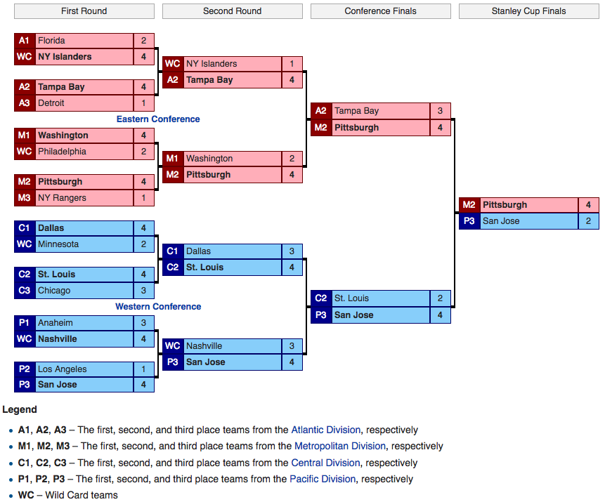

There’s another dataset from **Kaggle** under the same pro hockey database that breaks down team stats by month. **I want to plot out monthly win percentages for Stanley Cup winnning teams to see if they usually end with an upward trend.** The dataset is called `TeamSplits.csv`.

```r
splits <- read.csv("TeamSplits.csv")
teamsSplits <- full_join(splits, teams, by = c("year", "tmID"))
teamSplitsWinners <- teamsSplits %>%
  filter(playoff == 'SC')
nrow(teamSplitsWinners)
```

```
## [1] 97
```

Now we want to get the win percentages by month for every team and plot them if the teams ended on an upswing. Then by doing that, we’ll know how many (if any) of the Stanley Cup winners ended on a hot streak.  
**NOTE:** The way I’m calculating an upswing ending to the year is if `FebPct <= MarPct <= AprPct || FebPct <= MarPct`. I make this a two option thing because some teams either didn’t play regular season games in April (back in the old days) or play a rather negligible amount of games in April (like less than 5) so I don’t think it really matters too much if their record is still good (maybe like 2-2) if their Feb-March improvement is stellar.

```r
#Select the desired columns
tswbymonth <- teamSplitsWinners %>%
  select(year, tmID, OctW, OctL, NovW, NovL, DecW, DecL, JanW, JanL, FebW, FebL, MarW, MarL, AprW, AprL) %>%
#calculate win percentages by month
  mutate(OctPct = 100*OctW/(OctW+OctL), NovPct = 100*NovW/(NovW+NovL), DecPct =  100*DecW/(DecW+DecL), JanPct = 100*JanW/(JanW+JanL), FebPct = 100*FebW/(FebW+FebL), MarPct = 100*MarW/(MarW+MarL), AprPct = 100*AprW/(AprW+AprL))

#Fill the 'Hot' Column with NA's
tswbymonth <- tswbymonth %>%
  mutate(Hot = NA)

#Iterate over the column and assign values
for(i in 1:nrow(tswbymonth)){
  Feb <- tswbymonth[i, ]$FebPct
  Mar <- tswbymonth[i, ]$MarPct
  Apr <- tswbymonth[i, ]$AprPct
  if((Feb <= Mar && Mar <= Apr) || (Feb <= Mar)){
    tswbymonth[i, ]$Hot <- T
  } else{
    tswbymonth[i, ]$Hot <- F
  }
}
```

We need to `gather` the data into a better format, group by year and team, and arrange in descending order by year. We’re going to call it `tswbymonthP` where the P is for Plottable, because in the format it’s in now it can’t be plotted nicely.

```r
tswbymonthP <- gather(tswbymonth, "Month", "Percent", 17:23) %>%
  group_by(year, tmID) %>%
  arrange(desc(year))
head(tswbymonthP)
```

```
## Source: local data frame [6 x 19]
## Groups: year, tmID [1]
##
##    year   tmID  OctW  OctL  NovW  NovL  DecW  DecL  JanW  JanL  FebW  FebL
##   <int> <fctr> <int> <int> <int> <int> <int> <int> <int> <int> <int> <int>
## 1  2011    LAK     6     3     6     5     7     6     5     2     5     7
## 2  2011    LAK     6     3     6     5     7     6     5     2     5     7
## 3  2011    LAK     6     3     6     5     7     6     5     2     5     7
## 4  2011    LAK     6     3     6     5     7     6     5     2     5     7
## 5  2011    LAK     6     3     6     5     7     6     5     2     5     7
## 6  2011    LAK     6     3     6     5     7     6     5     2     5     7
## # ... with 7 more variables: MarW <int>, MarL <int>, AprW <int>,
## #   AprL <int>, Hot <lgl>, Month <chr>, Percent <dbl>
```

So now we have a table that is grouped by winner by year and the monthly percentage is in chronological order, it is more succeptible to plotting. But I need to group them by team and year. Programatically doing this is hard, so I’m going to suck it up and do it manually. But for the sake of these graphics, I’m only going use the Stanley Cup winners that won in seasons where they played from October to April. That includes winners from 1970-2012. So I will have a list of 42 instead of 97.

```r
lak2012 <- tswbymonthP[1:7, ]
bos2011 <- tswbymonthP[8:14, ]
chi2010 <- tswbymonthP[15:21, ]
pit2009 <- tswbymonthP[22:28, ]
det2008 <- tswbymonthP[29:35, ]
and2007 <- tswbymonthP[36:42, ]
car2006 <- tswbymonthP[43:49, ]
#2005 Lockout
tbl2004 <- tswbymonthP[50:56, ]
njd2003 <- tswbymonthP[57:63, ]
det2002 <- tswbymonthP[64:70, ]
col2001 <- tswbymonthP[71:77, ]
njd2000 <- tswbymonthP[78:84, ]
dal1999 <- tswbymonthP[85:91, ]
det1998 <- tswbymonthP[92:98, ]
det1997 <- tswbymonthP[99:105, ]
col1996 <- tswbymonthP[106:112, ]
njd1995 <- tswbymonthP[113:119, ]
nyr1994 <- tswbymonthP[120:126, ]
mtl1993 <- tswbymonthP[127:133, ]
pit1992 <- tswbymonthP[134:140, ]
pit1991 <- tswbymonthP[141:147, ]
edm1990 <- tswbymonthP[148:154, ]
cal1989 <- tswbymonthP[155:161, ]
edm1988 <- tswbymonthP[162:168, ]
edm1987 <- tswbymonthP[169:175, ]
mtl1986 <- tswbymonthP[176:182, ]
edm1985 <- tswbymonthP[183:189, ]
edm1984 <- tswbymonthP[190:196, ]
nyi1983 <- tswbymonthP[197:203, ]
nyi1982 <- tswbymonthP[204:210, ]
nyi1981 <- tswbymonthP[211:217, ]
nyi1980 <- tswbymonthP[218:224, ]
mtl1979 <- tswbymonthP[225:231, ]
mtl1978 <- tswbymonthP[232:238, ]
mtl1977 <- tswbymonthP[239:245, ]
mtl1976 <- tswbymonthP[246:252, ]
phi1975 <- tswbymonthP[253:259, ]
phi1974 <- tswbymonthP[260:266, ]
mtl1973 <- tswbymonthP[267:273, ]
bos1972 <- tswbymonthP[274:280, ]
mtl1971 <- tswbymonthP[281:287, ]
bos1970 <- tswbymonthP[288:294, ]
puck <- list(bos1970, mtl1971, bos1972, mtl1973, phi1974, phi1975, mtl1976, mtl1977, mtl1978, mtl1979, nyi1980, nyi1981, nyi1982, nyi1983, edm1984, edm1985, mtl1986, edm1987, edm1988, cal1989, edm1990, pit1991, pit1992, mtl1993, nyr1994, njd1995, col1996, det1997, det1998, dal1999, njd2000, col2001, det2002, njd2003, tbl2004, car2006, and2007, det2008, pit2009, chi2010, bos2011, lak2012)
```

So now we have data frames for every Stanley Cup winner from 1970-on. I ran into a problem whenever I tried to plot their win percentages though… Let’s see how the win percentages for Boston in 1970 looked over the course of the year.

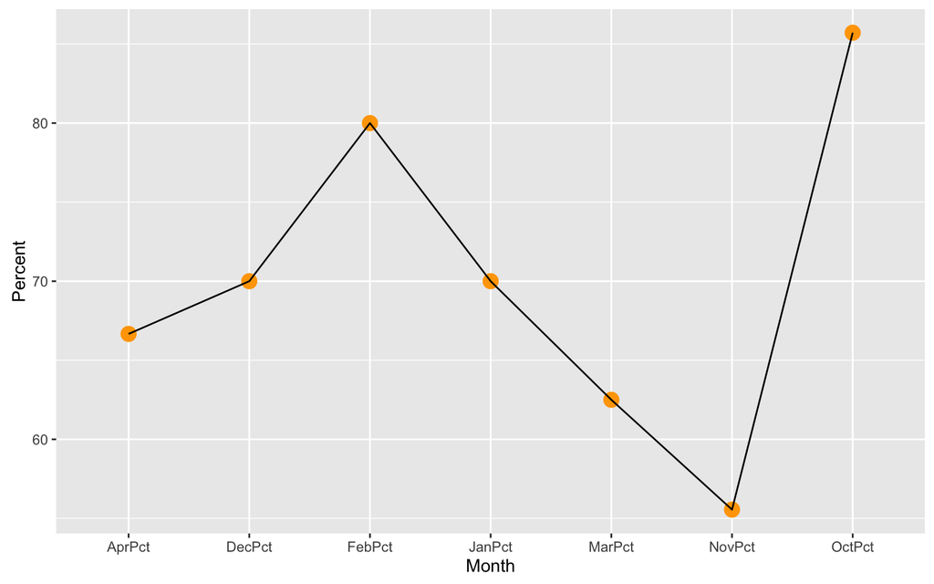

```r
ggplot(bos1970, aes(x=Month, y=Percent, group=1)) + geom_point(color = 'orange', size = 4) + geom_line()
```

Notice how the months are ordered on the x-axis- *alphabetically*. That’s no good. I want them ordered *chronologically*. I found [this](https://stackoverflow.com/questions/12774210/how-do-you-specifically-order-ggplot2-x-axis-instead-of-alphabetical-order) question on **StackOverflow** that helped me very much. Turns out getting ggplot to keep the order of your axes is harder than it should be…

```r
plts <- list()
hotTeams <- list()
for(p in 1:length(puck)){
  dat <- puck[[p]]
  #StackO said to transform your column to character
  dat$Month <- as.character(dat$Month)
  #then reorder it as factor in the unique levels it's in
  dat$Month <- factor(dat$Month, levels = unique(dat$Month))
  #append ggplot statement to list plts
  plts[[p]] <- ggplot(dat, aes(x=Month, y=Percent, group=1)) + geom_point(color='orange', size=4) + geom_line()
}
```

So what I’ve basically made is a list of plots that I can call and it will plot for me. How did Boston **ACTUALLY** do that year?

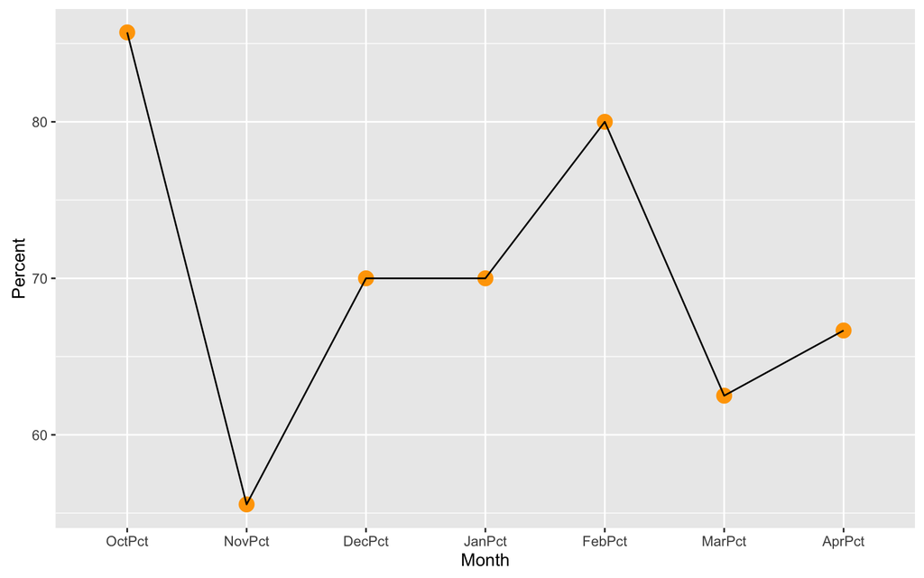

```r
plts[[1]]
```

This graph looks good! So Boston didn’t necessarily end “hot”. And believe it or not, I found as a side effect that you can store ggplot statements in a list and call those plots by referencing a position in the list. In theory, it makes sense that you should be able to do that, but when R actually allowed me to do it I thought it was very cool.  
So let’s find out a few things:  
1)- How many teams that won the Stanley Cup were “hot”?  
2)- What percentage of Stanley Cup winners ended on a “hot” streak?  
This will really tell me if it’s all about timing.  
On with the coding…

```r
#Keep the hot teams
hotTeams <- tswbymonth %>%
  filter(Hot == T)
nrow(hotTeams)
```

```
## [1] 48
```

```r
#Percentage of teams that won that ended hot
100*nrow(hotTeams)/nrow(tswbymonth)
```

```
## [1] 49.48454
```

Ok, so 48/97 Stanley Cup winning teams were *hot* at the end of their season. That’s only about 50%. A 50/50 split doesn’t tell me much about whether being hot at the end of a season helps you win the cup. **BUT**- what if we calculated for ALL the teams over ALL the years if they ended hot- and of those teams, how many won the cup? One question leads to another! This shouldn’t be that hard though.

```r
#teamsSplits doesn't have monthly win percentages. Make that happen by reusing code
teamsSplits <- teamsSplits %>%
  select(year, tmID, OctW, OctL, NovW, NovL, DecW, DecL, JanW, JanL, FebW, FebL, MarW, MarL, AprW, AprL) %>%
#calculate win percentages by month
  mutate(OctPct = 100*OctW/(OctW+OctL), NovPct = 100*NovW/(NovW+NovL), DecPct =  100*DecW/(DecW+DecL), JanPct = 100*JanW/(JanW+JanL), FebPct = 100*FebW/(FebW+FebL), MarPct = 100*MarW/(MarW+MarL), AprPct = 100*AprW/(AprW+AprL))

#Same thing first, initialize the Hot column
teamsSplits <- teamsSplits %>%
  mutate(Hot = NA)
```

I’m breaking these code chunks up for easier readability. I spoke too soon, this is hard.

```r
#Problem 1)- program trips up on instances where March is NA, so omit those rows
teamsSplits <- teamsSplits %>% drop_na(FebW, FebL, MarW, MarL)
```

**StackOverflow Problem 1)-** [Third answer down uses tidyr](https://stackoverflow.com/questions/4862178/remove-rows-with-nas-missing-values-in-data-frame)

```r
#Problem 2)- some teams that lose all their games in given month have a monthly percentage of NaN rather than 0. Fix those values to be 0
#create a function
is.nan.data.frame <- function(x)
do.call(cbind, lapply(x, is.nan))

teamsSplits[is.nan(teamsSplits)] <- 0
```

**StackOverflow Problem 2)-** [Third answer down creates the function](https://stackoverflow.com/questions/18142117/how-to-replace-nan-value-with-zero-in-a-huge-data-frame)

```r
#Now let's loop through and assign values
for(i in 1:nrow(teamsSplits)){
  Feb <- teamsSplits[i, ]$FebPct
  Mar <- teamsSplits[i, ]$MarPct
  Apr <- teamsSplits[i, ]$AprPct
  if((Feb <= Mar && Mar <= Apr) || (Feb <= Mar)){
    teamsSplits[i, ]$Hot <- T
  } else{
    teamsSplits[i, ]$Hot <- F
  }
}
```

We need to join tables with `teams` for the `playoff` column to see who actually won the Cup.

```r
teamsSplits2 <- full_join(teamsSplits, teams, by = c("year", "tmID"))
```

I know this logic is getting messy, but stick with me. I’ll produce something of worth with some more troubleshooting and messy code!  
Now let’s see if we can dig down to **find the percentage of hot teams that go on to win the cup.**

```r
teamsSplits2 <- teamsSplits2 %>%
  filter(Hot == T)
teamSplitsWinners2 <- teamsSplits2 %>%
  filter(playoff == 'SC')
nrow(teamsSplits2)
```

```
## [1] 58
```

```r
nrow(teamSplitsWinners2)
```

```
## [1] 5
```

```r
100*nrow(teamSplitsWinners2)/nrow(teamsSplits2)
```

```
## [1] 8.62069
```

### Montreal- Was the Best Team Ever a “Hot” Team?

[figure not shown]

[figure not shown]

Apparently the top team ever in the NHL was the 1976-77 Montreal Canadiens. They did indeed win- A LOT- in ’76 for 4 in a row till ’80. Did they end on a hot streak?

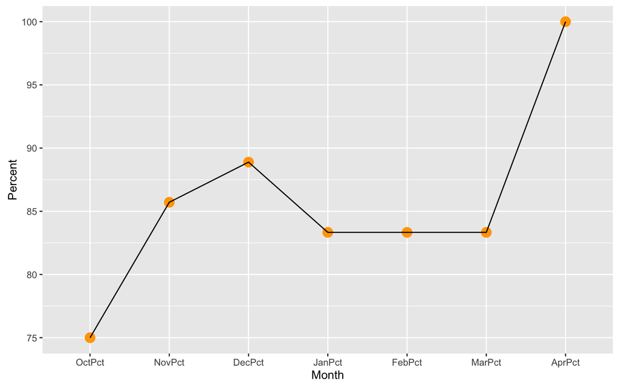

```r
plts[[7]]
```

Above: **Montreal in ’75-’76**

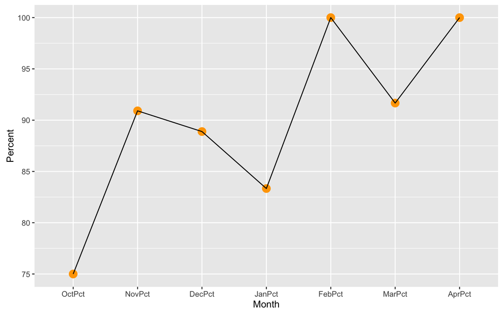

```r
plts[[8]]
```

Above: **Montreal in ’76-’77**

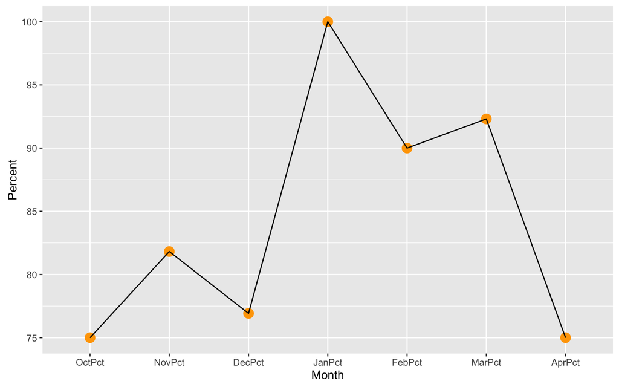

```r
plts[[9]]
```

Above: **Montreal in ’77-’78**

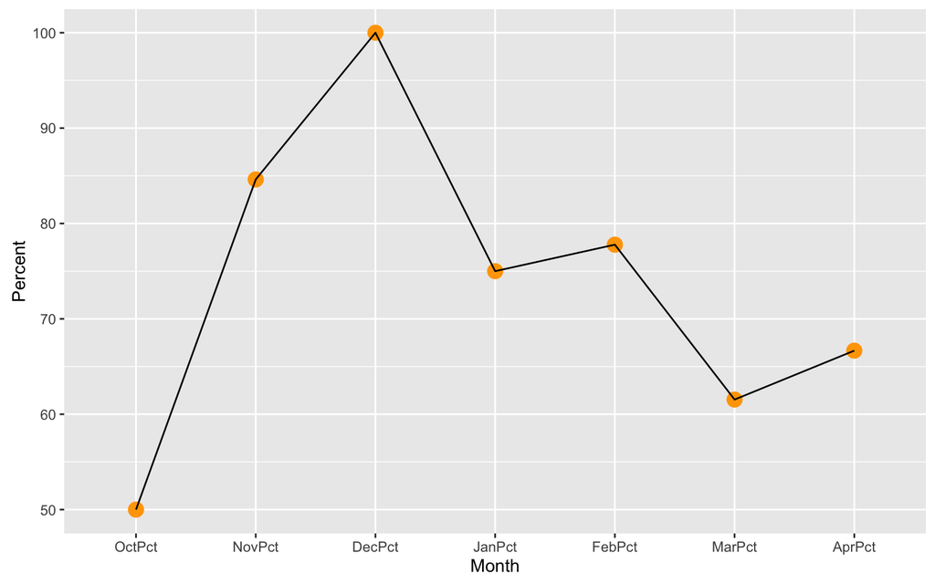

```r
plts[[10]]
```

### Machine Learning in Hockey

That 8% was still a tough one to swallow… but I have one more trick up my sleeve… **Machine Learning!**. Let’s see if any basic decision trees can give me any tips on what a team has to do to maximize their chance of winning the cup.  
First we need to transform `teamsSplits` back to how it was.

```r
teamsSplits <- full_join(splits, teams, by = c("year", "tmID"))
```

Now we can continue on with the Machine Learning.

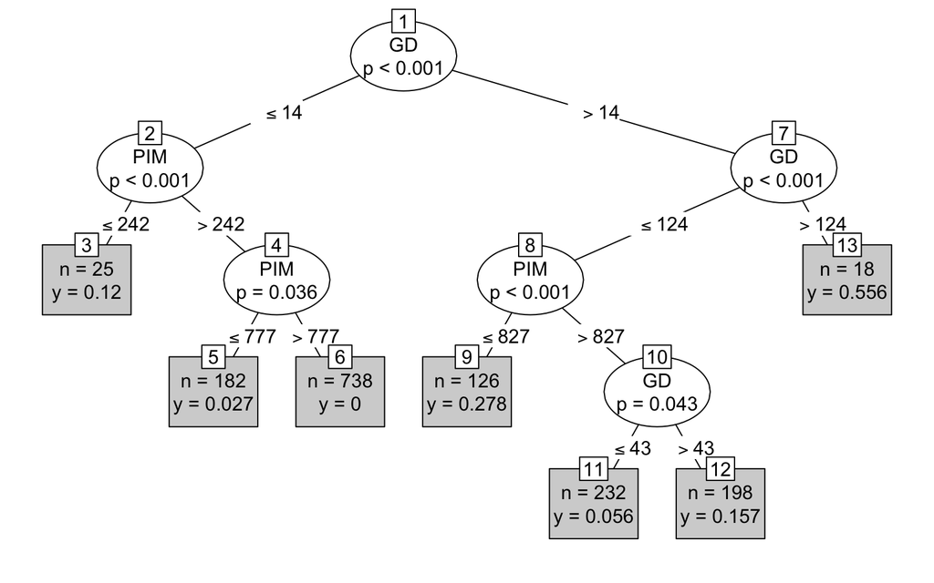

```r
mod1 <- party::ctree(playoff == 'SC' ~ Pts + GD + PIM + PPG, data = teamsSplits)
plot(mod1, type = "simple")
```

Ok, so with a goal differential greater than 124, you’ve got a 55.6% chance of winning the cup. Great, THANKS `party`- you drastically improved something I already tried to explore. Well let’s see what the `log_likelihood` is for this model. We want a `log_likelihood` of as close to 0 as possible.

```r
teamsSplits %>%
  mutate(probability = as.numeric(predict(mod1)),
         likelihood =
           ifelse(playoff == 'SC',
                  probability,
                  1 - probability)) %>%
  summarise(log_likelihood = sum(log(likelihood)))
```

```
##   log_likelihood
## 1      -254.8984
```

Ok, I think this is decent. In the Machine Learning Activity we did in class, we were getting values in the negative 6 and 4 thousands, so this model must be decently confident. Though, I do believe we are working with significantly less data. I digress…  
Let’s see if we can improve our model by adding some better things and taking some things away.

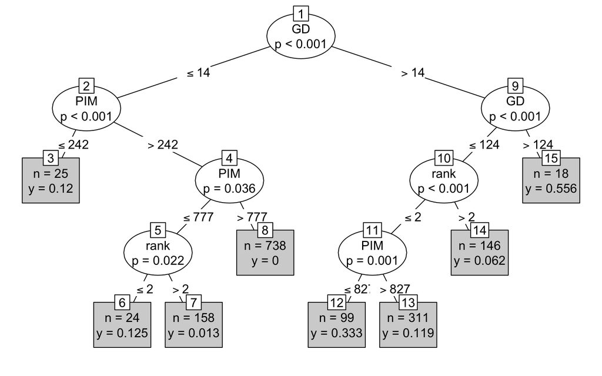

```r
mod2 <- party::ctree(playoff == 'SC' ~ GD + PIM + MarW + rank, data = teamsSplits) #add March Wins and rank, get rid of Pts and PPG
plot(mod2, type = "simple")
```

Ok so no real change in our success rate. Is this a better model?

```r
teamsSplits %>%
  mutate(probability = as.numeric(predict(mod2)),
         likelihood =
           ifelse(playoff == 'SC',
                  probability,
                  1 - probability)) %>%
  summarise(log_likelihood = sum(log(likelihood)))
```

```
##   log_likelihood
## 1      -251.5907
```

Barely. Let’s keep trying out some variable combinations.

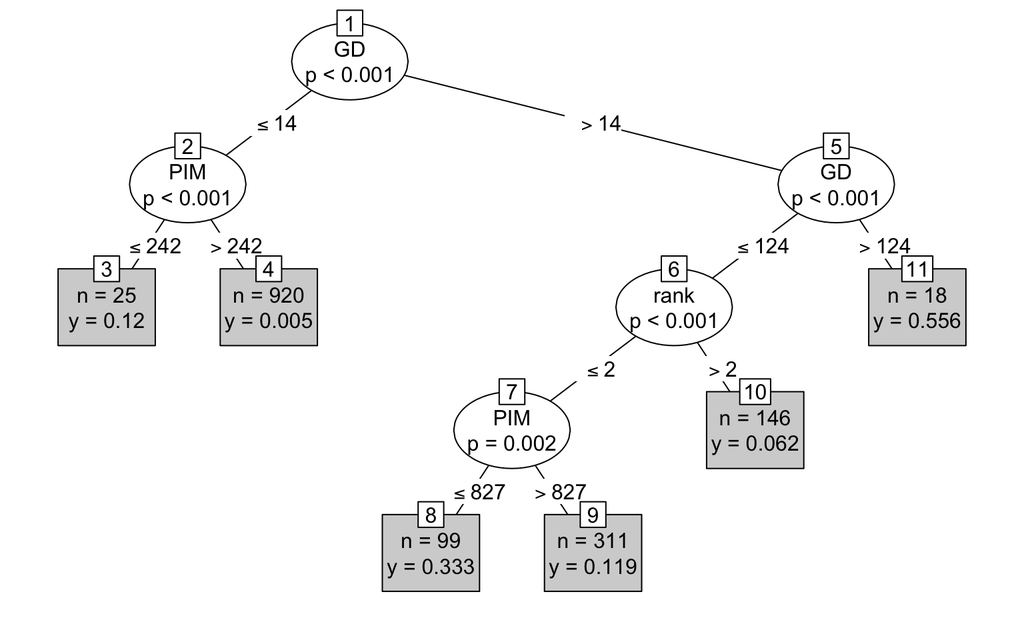

```r
mod3 <- party::ctree(playoff == 'SC' ~ Pts + MarW + rank + GD + PIM + PPG, data = teamsSplits)
plot(mod3, type = "simple")
```

Is this a better model?

```r
teamsSplits %>%
  mutate(probability = as.numeric(predict(mod3)),
         likelihood =
           ifelse(playoff == 'SC',
                  probability,
                  1 - probability)) %>%
  summarise(log_likelihood = sum(log(likelihood)))
```

```
##   log_likelihood
## 1      -262.8831
```

Nope, it’s worse. So I’m gonna call it here and say that our best model is indeed `mod2`. I’m sure it can be improved, but this has been a tiresome Exploratory Data Analysis, so I’m going to wrap it up.

### Things I Wish to Improve On in the Future

**1)-** I am not happy with the organization of my code, but I hope you were able to follow it. I would spend countless hours trying to clean it up, but a wise professor I had once told me “If it works, who cares- you’re not a computer scientist”.  
**2)-** I wish to improve upon my machine learning algorithms. Hopefully with time, exploration, and coursework, I can come to better understand machine learning and what goes into making a good model. Just in looking on the internet, people haven’t done much in terms of machine learning applied to hockey, so maybe I could be the pioneer there to develop an algorithm to predict Stanley Cup winners! It will be in the back of my mind.